# Data Evaluation of previous Field Trips and Prediction on potential revisit farms

## The Hybrid Index

Supposedly originating from the Indo-Pakistani Cradle, house mice have followed human population and thereby diverged into different subspecies. Over time, two populations diverged in allopatry for almost 500.000 years and now meet again in the so-called House Mouse Hybrid Zone (HMHZ).

This zone stretches all across Europe, reaching from Scandinavia to the Black Sea, thereby covering more than 2500km in length, and 20km in width (Baird & Macholán, 2012; Boursot et al., 1993; Jones, Kooij, Solheim, & Searle, 2010; Macholán, Kryštufek & Vohralík, 2003). It constitutes a narrow band that builds a reconnection zone for two house mouse subspecies: The Western and the Eastern House mouse. Although they differ in physical traits, they still reproduce with one another and thereby cause the formation of hybrids over time. It has been proven that hybrids tend to withstand parasitic infections, while suffering in reproductive traits compared to non-hybrid individuals.

In previous years, numerous wild samples have been collected in the HMHZ to gain insight into genetic, reproductive, and ecological differences. The Hybrid Index (HI) is calculated by evaluating the presence or absence of specific loci. Generally, presence of 14 loci is associated with a pure Mmm (Eastern House mouse, Mus musculus musculus), whereas missing of said loci indicates a pure Mmd (Western House mouse, Mus musculus domesticus), and anything in between is considered a hybrid, although measurements have been refined over time (Jarda et al.)

HI Data is available for samples since 2010, although Crypto-specific data has only been collected with qPCRs for samples since 2016.

[interactive chart not shown]

## Crypto-positive mice

Since 2016, qPCRs were used to identify Crypto-positive mice. Dilution curves with known Oocyst-DNA concentrations were run on the same plate as unknown samples to generate a Standard Curve, which should resemble a (log2) linear function.

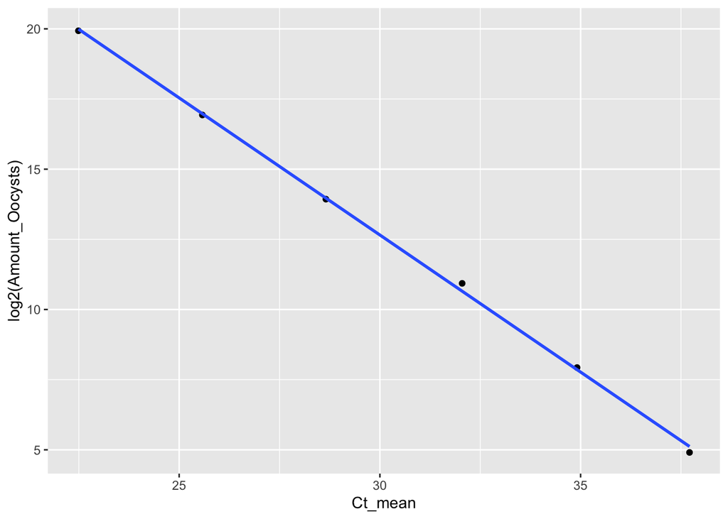

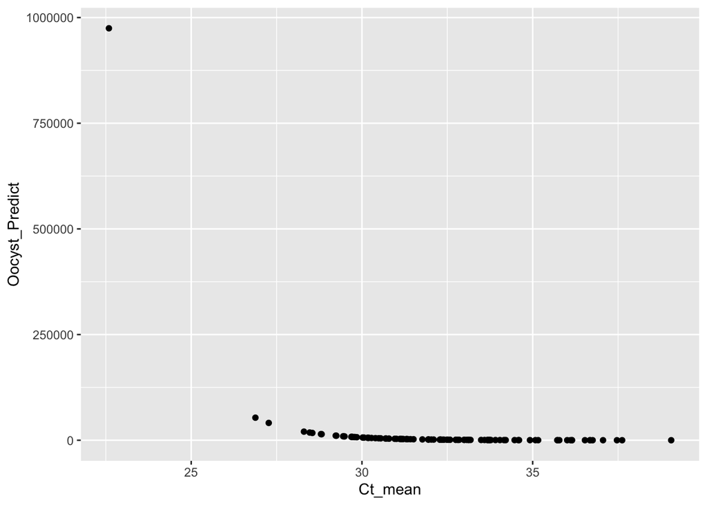

```
##   Year mus_per_Yr Crypto_per_Yr Prevalence
## 1 2016        137            15   10.94891
## 2 2017        201            50   24.87562
## 3 2018        152            20   13.15789
## 4 2019        132            16   12.12121
```

Here the Crypto-positive cases per mice caught are visualized per year.

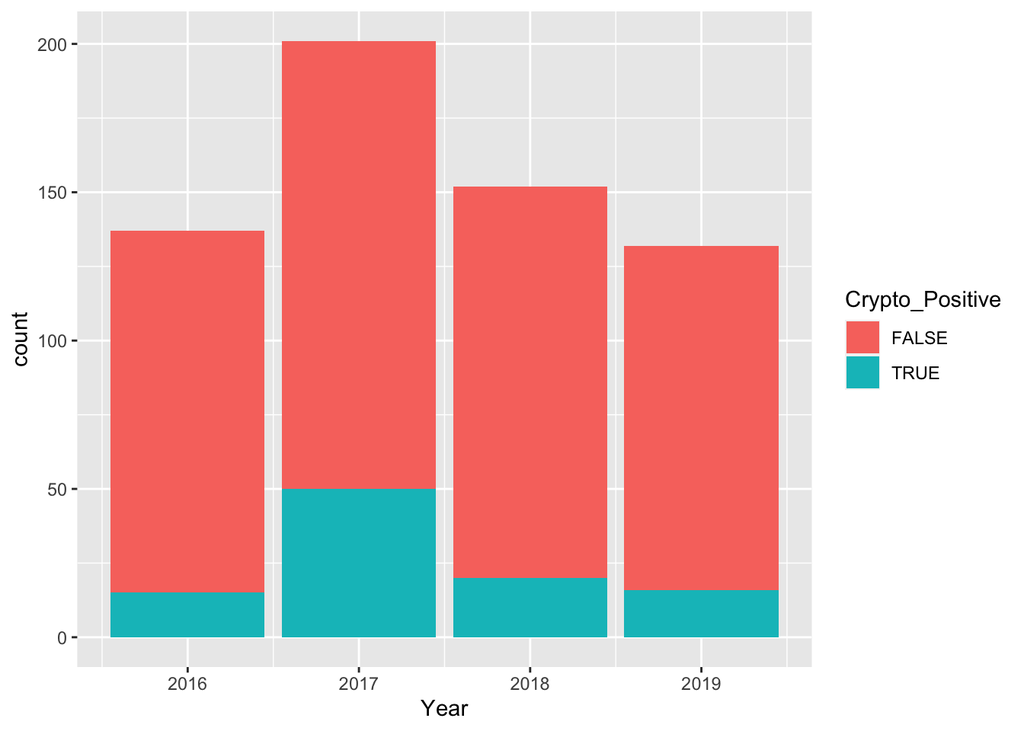

## Finding Crypto-positive Locations

It is likely that multiple Crypto-positive mice have been caught in the same locality, not only during the same sampling year, but also in different years, if the location was revisited by chance. Therefore each location was tested for the amount of Crypto-infected and non-Crypto-infected mice caught there, and the Infection rate of Crypto-positive vs. all mice was calculated.

[interactive chart not shown]

So overall, there are a many locations where few Crypto-positive mice were caught, while few locations yielded many Crypto-positive samples.

```
##    Latitude Longitude mus_caught Crypto_per_Location
## 1   53.0497   13.4408         17                   8
## 2   52.0747   14.1808         10                   7
## 3   52.8969   13.5353         14                   6
## 4   53.1275   13.4864          9                   5
## 5   53.1422   13.9533          8                   5
## 6   52.0172   14.1442          7                   4
## 7   52.2125   14.0922          9                   4
## 8   52.8328   14.0908          5                   3
## 9   52.9581   13.8950          5                   3
## 10  52.9783   13.7336         12                   3
## 11  52.9936   13.3047         21                   3
## 12  53.0783   14.1414         17                   3
```

## Top Farms from previous Years

| Top Farm | Address | Latitude | Longitude |
| --- | --- | --- | --- |
| 1 | Storkower Dorfstraße 85-82, 17268 Templin | 53.0497 | 13.4408 |
| 2 | Sawaller Dorfstraße 34A, 15848 Tauche | 52.0747 | 14.1808 |
| 3 | Berliner Str. 28, 16244 Schorfheide | 52.8969 | 13.5353 |
| 4 | near Lychener Str. 28, 17268 Templin | 53.1275 | 13.4864 |
| 5 | Dorfstraße 28, 16278 Angermünde | 53.1422 | 13.9533 |
| 6 | Guhlen 29, 15913 Schwielochsee | 52.0172 | 14.1442 |
| 7 | Beeskower Str. 24, 15848 Rietz-Neuendorf | 52.2125 | 14.0922 |
| 8 | Altglietzener Dorfstraße 31, 16259 Bad Freienwalde (Oder) | 52.8328 | 14.0908 |
| 9 | Kirchstraße 1, 16247 Joachimsthal | 52.9581 | 13.8950 |
| 10 | Zehdenicker Str. 8, 16247 Joachimsthal | 52.9783 | 13.7336 |
| 11 | Mildenberger Str. 1, 16792 Zehdenick | 52.9936 | 13.3047 |
| 12 | Hauptstraße 5, 16278 Mark Landin | 53.0783 | 14.1414 |

## Potential Locations 2021

[interactive chart not shown]

## Trustable qPCR results from previous years

```
##   Flag_Ct_1_Ep   n
## 1        FALSE 350
## 2         TRUE 162
## 3           NA 305
```

```
##   Flag_Ct_2_Ep   n
## 1        FALSE 465
## 2         TRUE  47
## 3           NA 305
```

```
##   Flag_Ct_3_Ep   n
## 1        FALSE  18
## 2         TRUE   5
## 3           NA 794
```

```
##   Flag_Ct_4_Ep   n
## 1        FALSE  23
## 2           NA 794
```

```
##   Flag_Ct_5_Ep   n
## 1         TRUE   2
## 2           NA 815
```

```
##   Flag_Ct_6_Ep   n
## 1        FALSE   2
## 2           NA 815
```